# Somateria mollissima escape distance

V. Khaitov

### Фильтрация данных

Итак, мы точно удаляем все гнезда, где больше 6 яиц. Аргументы в пользу этого меня пока не убеждают, но да ладно.

Было: 3199 гнезда.

Стало: 3034 гнезда.

Далее, предлагается удалять те гнезда в которых неполная кладка. Признаки таких гнезд следующие.

1. Яиц в гнезде мало, пусть 3 и меньше.
2. Яиц с диаметрами в кладке нет.
3. Все яйца имеют углы меньше 30 градусов.

Всего таких гнезд 43.

Однако, почитав работу Корякина, я прихожу к выводу, что он не удалял такие гнезда из обсчетов. Вот почему.

Смотрим на формулу, которую он вводит:

$$Ed = \frac{Q}{\lg(Tinc + 2)}$$
АСК полагал, что у каждой гаги есть некоторая индивидуальная харкатеричстика $Q$, которая характеризует индивидуальную осторожность. Теоретически, наличие такой характеристики возможно. Хотя, по-моему, требует доказательств, по, меньшей мере, формы связи. Почему отношение, а не линейная связь? Почему десятичный логарифм, а не степенная зависимость? Все это как-то вводится, как данность. НО! Речь не про это. Важно понять откуда в формуле +2. Так вот, это от того, что логарифм нуля неопределен, поэтому чтобы при логарифмировании было в итоге нулевое значение в практике статистики принято писать $lg(x+1)$. Однако, при Tinc=0 отношение превращается в бесконечность, что тоже не супер. Поэтому АСК добавляет двойку. Следовательно, он в этой формуле подразумевает, что Tinc может быть равно нулю. Ноль же может быть только если все изученные яйца в кладке имеют угол равный нулю. При всех остальных комбинациях Tinc нулем оказаться не может. Поэтому данная формула подразумевает наличие гнезд, в которых все исследованные яйца имеют угол ноль, а это может быть, в том числе, и при неполной кладке. Короче, я за то, чтобы фильтрации по этому признаку не проводить.

Пока не провожу.

Итого, зависимая переменная в дальнейшем анализе - это $Q = Ed \cdot \lg(Tinc + 2)$.

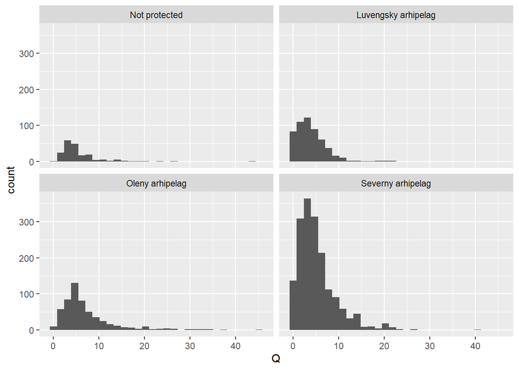

Зависимая переменная сильно асимметрично распределена. И это проблема. Я долго мучился и так и не смог найти какой-то правильный тип распределения, который позволил бы подобрать работающую модель.

Следующая проблемы в материале связана с тем, что фактор “Region” сильно коррелирует с основными пердикторами (Dist_to_town И Dist_to_Mainland). Коррелирующие факторы изучать трудно и в строгом анализе надо включать только один из них. Пока убрал фактор регион из модели, но рассмотрел влияние основных фкторов отдельно для каждого региона.

Далее есть проблема с группой, которую я обозначил как Not_protected. Это Малый и Половиница. Если вводить такую градацию, то в ней всего две локации, а стало быть влияние Dist_to_town И Dist_to_Mainland оценивается только по двум точкам. Это совсем плохо. Поэтому либо эти острова включать в Олений архипелаг, либо выкидывать из анализа. Включил их в Олений архипелаг.

Пока модель выглядит вот так.

```r
som_isl_region_joined <-  som_isl

som_isl_region_joined$Region_3 <- som_isl_region_joined$Region_2

som_isl_region_joined$Region_3[som_isl_region_joined$Region_3 == "Not protected"] <- "Oleny arhipelag"

         # в Not protected нет варьирования по расстояниям до материака и до населенных пунктов!

som_isl_region_joined$Region_3 <- factor(som_isl_region_joined$Region_3)

mod <- bam(Q ~
             s(Year, k = 6) +
             s(N_eggs, k = 4, by = Region_3) +
             s(Log_Area, by = Region_3) +
             s(log(Dist_to_Mainland), by = Region_3) +
             s(log(Dist_to_town), by = Region_3)  +
             # Region_2 + регионы коллинеарны расстояниям до материка и до населенных пунктов
             s(Place, k = 87, bs = "re"),
           family = tw(link = "log"),
           data = som_isl_region_joined)
```

Проверяем валидность модели

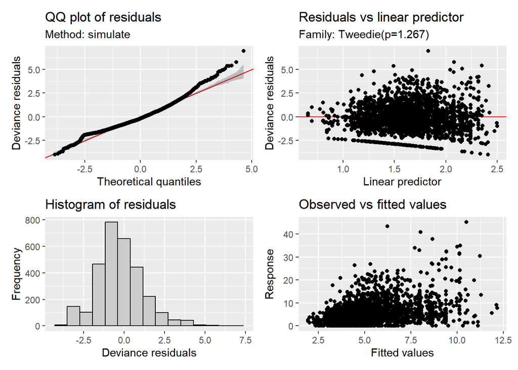

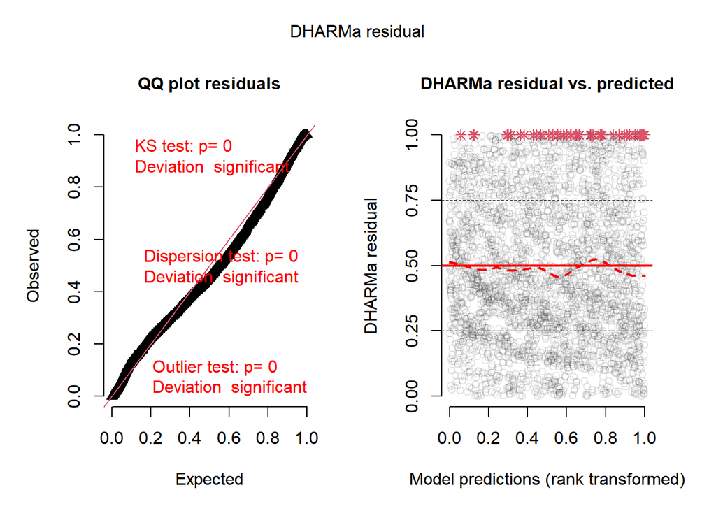

```
## Object of Class DHARMa with simulated residuals based on 250 simulations with refit = FALSE . See ?DHARMa::simulateResiduals for help.
##
## Scaled residual values: 0.752 0.888 0.82 0.668 0.256 0.368 0.72 0.38 0.924 0.416 0.488 0.03592122 0.196 0.04093206 0.3 0.3 0.992 0.748 0.28 0.472 ...
```

Диагностика модели плохая. Это означает, что слишком доверять ее результатам нельзя. Но это лучшая модель, которую мне удалось построить.

Вот summary от этой модели

```
##
## Family: Tweedie(p=1.267)
## Link function: log
##
## Formula:
## Q ~ s(Year, k = 6) + s(N_eggs, k = 4, by = Region_3) + s(Log_Area,
##     by = Region_3) + s(log(Dist_to_Mainland), by = Region_3) +
##     s(log(Dist_to_town), by = Region_3) + s(Place, k = 87, bs = "re")
##
## Parametric coefficients:
##             Estimate Std. Error t value Pr(>|t|)
## (Intercept)  1.62794    0.05163   31.53   <2e-16 ***
## ---
## Signif. codes:  0 '***' 0.001 '**' 0.01 '*' 0.05 '.' 0.1 ' ' 1
##
## Approximate significance of smooth terms:
##                                                         edf Ref.df      F
## s(Year)                                               2.769  3.399 12.929
## s(N_eggs):Region_3Luvengsky arhipelag                 1.074  1.144  1.064
## s(N_eggs):Region_3Oleny arhipelag                     1.122  1.231 10.627
## s(N_eggs):Region_3Severny arhipelag                   1.000  1.001 13.810
## s(Log_Area):Region_3Luvengsky arhipelag               1.947  2.144  1.049
## s(Log_Area):Region_3Oleny arhipelag                   1.000  1.000  9.540
## s(Log_Area):Region_3Severny arhipelag                 1.174  1.211  0.771
## s(log(Dist_to_Mainland)):Region_3Luvengsky arhipelag  2.601  2.970  2.015
## s(log(Dist_to_Mainland)):Region_3Oleny arhipelag      2.406  2.660  4.849
## s(log(Dist_to_Mainland)):Region_3Severny arhipelag    1.000  1.000  9.172
## s(log(Dist_to_town)):Region_3Luvengsky arhipelag      2.865  3.165  3.157
## s(log(Dist_to_town)):Region_3Oleny arhipelag          1.000  1.000  2.964
## s(log(Dist_to_town)):Region_3Severny arhipelag        1.000  1.000  9.778
## s(Place)                                             33.144 79.000  1.396
##                                                       p-value
## s(Year)                                               < 2e-16 ***
## s(N_eggs):Region_3Luvengsky arhipelag                0.271509
## s(N_eggs):Region_3Oleny arhipelag                    0.000942 ***
## s(N_eggs):Region_3Severny arhipelag                  0.000206 ***
## s(Log_Area):Region_3Luvengsky arhipelag              0.406568
## s(Log_Area):Region_3Oleny arhipelag                  0.002028 **
## s(Log_Area):Region_3Severny arhipelag                0.504620
## s(log(Dist_to_Mainland)):Region_3Luvengsky arhipelag 0.111510
## s(log(Dist_to_Mainland)):Region_3Oleny arhipelag     0.003366 **
## s(log(Dist_to_Mainland)):Region_3Severny arhipelag   0.002479 **
## s(log(Dist_to_town)):Region_3Luvengsky arhipelag     0.020983 *
## s(log(Dist_to_town)):Region_3Oleny arhipelag         0.085216 .
## s(log(Dist_to_town)):Region_3Severny arhipelag       0.001783 **
## s(Place)                                              < 2e-16 ***
## ---
## Signif. codes:  0 '***' 0.001 '**' 0.01 '*' 0.05 '.' 0.1 ' ' 1
##
## R-sq.(adj) =  0.114   Deviance explained = 14.1%
## fREML = 5599.4  Scale est. = 1.8124    n = 3027
```

Итого, значимые связи, согласно этой несовершенной модели, выявляются со следующими непрерывными ковариатами:

Year (см. ниже) Надо думать почему есть многолетняя динамика.

N_eggs - только на Оленьем и Северном архипелаге

Log_Area (Размер острова) - только на Оленьем архипелаге

Dist_to_Mainland значимая связь только для Оленьего и Северного. Возможно это связано с тем, что в Лувеньге все рядом с материком.

Dist_to_town связь выявлена только для Лувеньги и Севетрного.

НО! Везде не стоит серьезно рассмтаривать те случаи, где p-value близко к 0.05. Модель все-таки, я считаю, плохая.

#### Многолетняя динамика

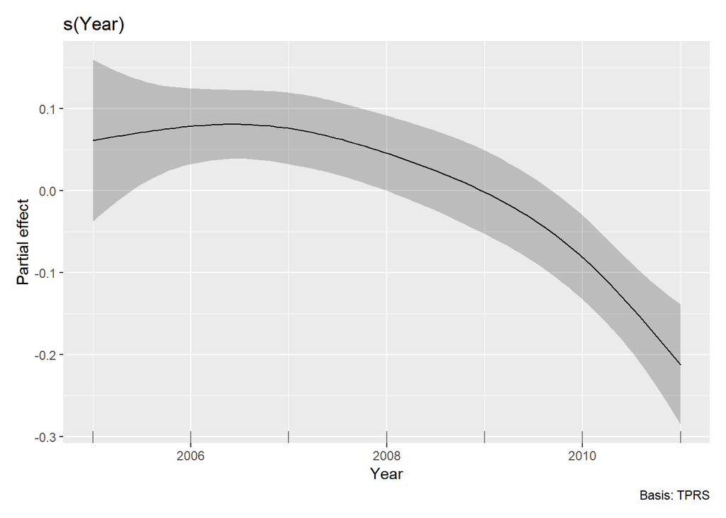

Думаем!!! Боюсь, это человеческий фактор.

#### Количество яиц

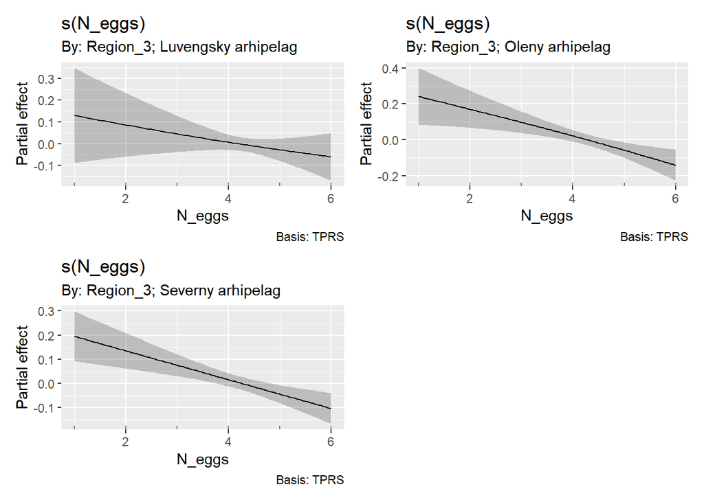

Эта связь, скорее всего означает, что если уж гага вложилась в большое количесто яиц, то надо сидеть до последнего. Следовательно Q падает. Если яиц мало, то проще все бросить (быть более осторожной).

#### Размер острова

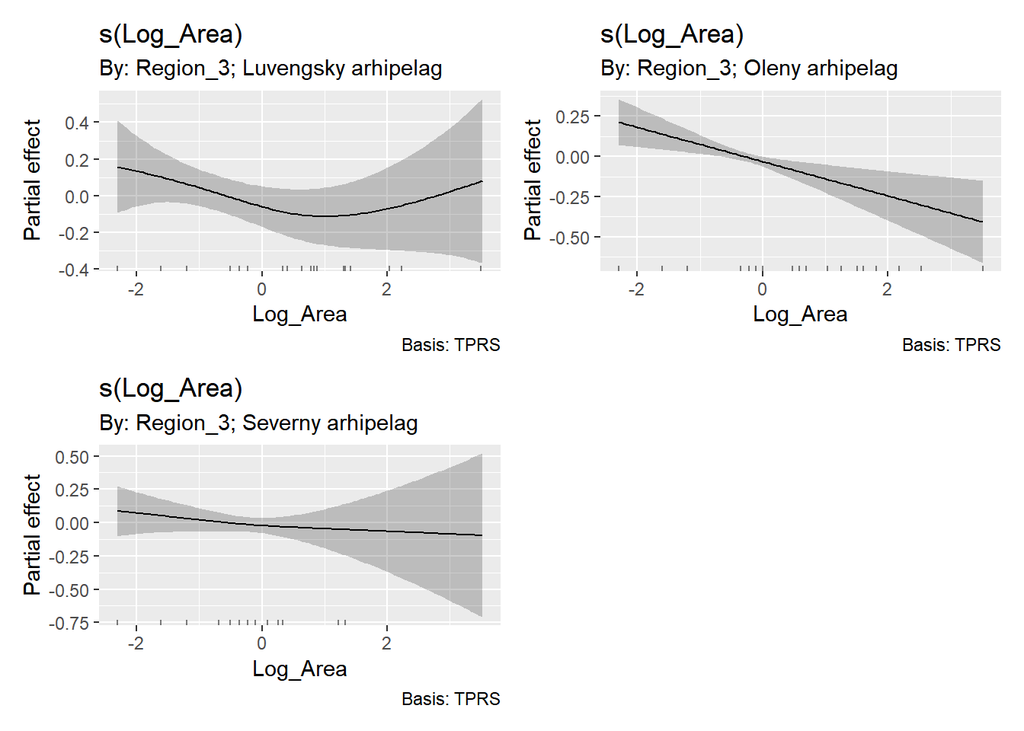

Думаем… Здесь связь есть только на Оленьем архипелаге. Может в этом и есть какая-то осмысленность.

#### Растояние до материка

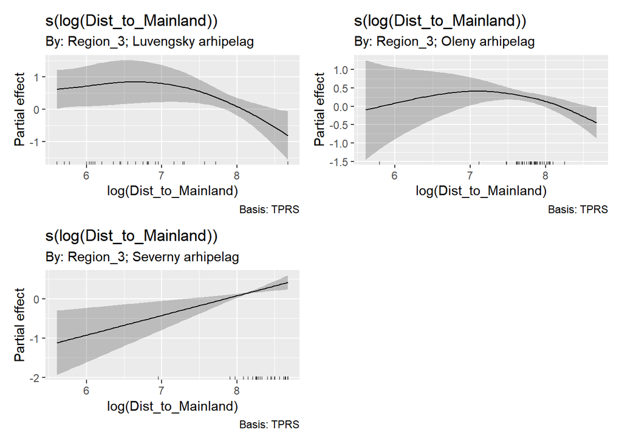

Забавно… В прибрежных регионах (Лувеньга и Олений) - чем ближ к материку, тем осторожнее. А в мористом регионе (Северный) наоброт. Возможно, что здесь тоже есть ккая-то биология.

#### Растояние до ближайшего населенного пункта

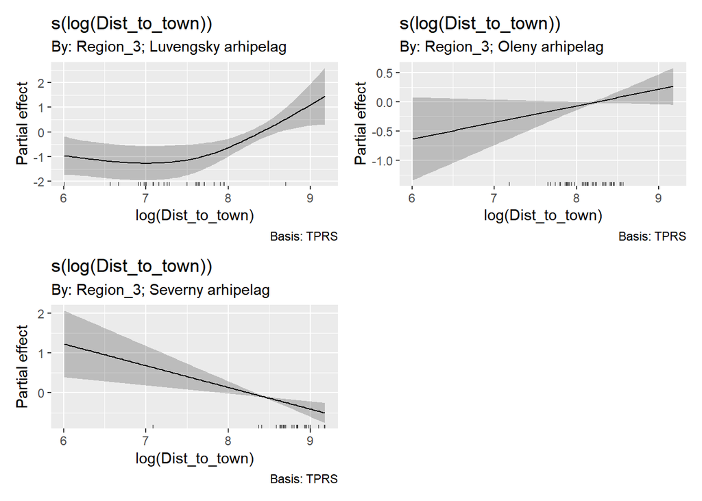

Опять же разнонаправленная связь в Лувеньге и на Северном архипелаге.